# Week4_Exercises

Priya Shaji

9/17/2020

## Forecasting Principles and Practice

### Load required packages

```r
packages <- c("tidyverse", "fpp2", "forecast", "kableExtra", "broom", "ggplot2", "caret", "e1071", "knitr", "GGally", "VIM", "mlbench", "car", "corrplot", "mice", "seasonal", "fma", "latex2exp","gridExtra")
pacman::p_load(char = packages)
```

#### 6.2

**The plastics data set consists of the monthly sales (in thousands) of product A for a plastics manufacturer for five years.**

1. Plot the time series of sales of product A. Can you identify seasonal fluctuations and/or a trend-cycle?
2. Use a classical multiplicative decomposition to calculate the trend-cycle and seasonal indices.
3. Do the results support the graphical interpretation from part a?
4. Compute and plot the seasonally adjusted data.
5. Change one observation to be an outlier (e.g., add 500 to one observation), and recompute the seasonally adjusted data. What is the effect of the outlier?
6. Does it make any difference if the outlier is near the end rather than in the middle of the time series?

**Answer**

**a. Plot the time series of sales of product A. Can you identify seasonal fluctuations and/or a trend-cycle?**

Let’s use autoplot to see the fluctuations in trend cycle of sales of product A

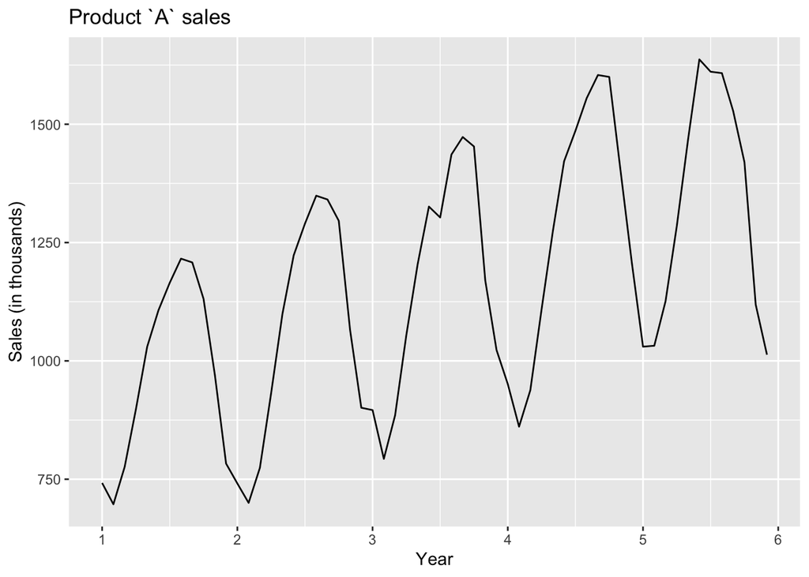

```r
autoplot(plastics) +
  ggtitle("Product `A` sales") +
  xlab("Year") +
  ylab("Sales (in thousands)")
```

The plot show that the data is highly seasonal and with a consistent positive trend. It also appears that the height of the seasonal trends appear to increase with time.

Now let’s use `ggseasonplot()` to analyze seasonal components of `plastics` data

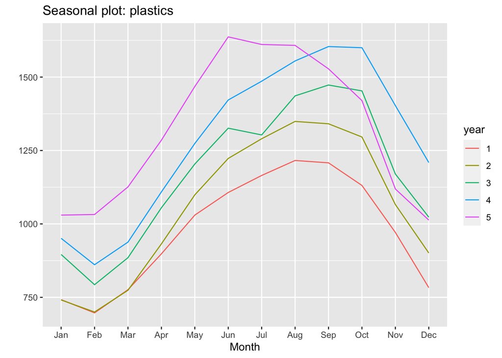

```r
ggseasonplot(plastics)
```

The plastics data has has an increasing trend, increases with time and a seasonal component where sales are higher in the summer and lower in the winter.

**b. Use a classical multiplicative decomposition to calculate the trend-cycle and seasonal indices.**

**Answer**

Let’s use `decompose()` function to calculate the trend-cycle and seasonal indices

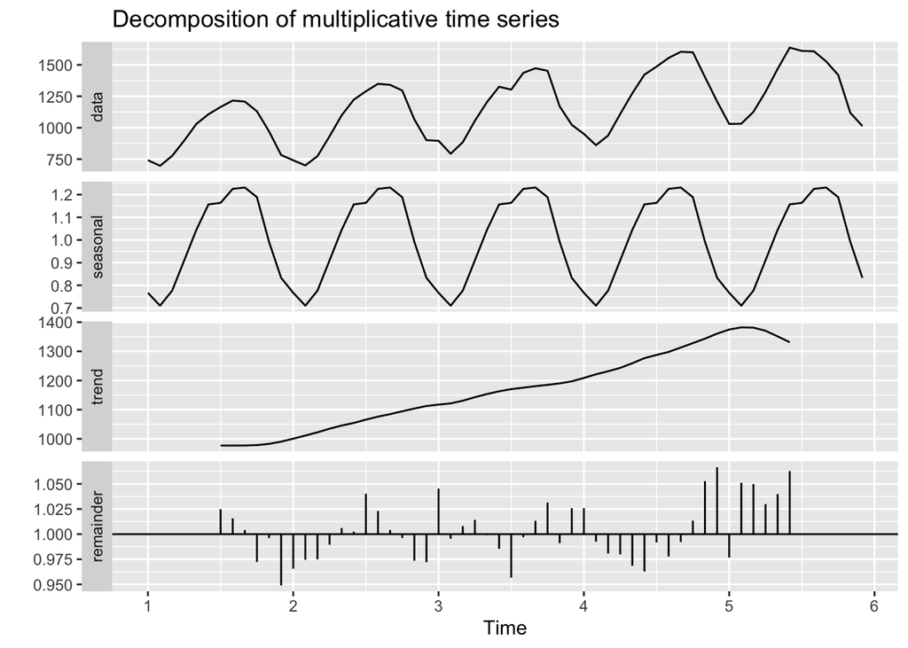

```r
plastics %>% decompose(type="multiplicative") %>%
  autoplot()
```

**c. Do the results support the graphical interpretation from part a?**

**Answer**

Yes, the results of decomposition of multiplicative time series support the features of the data being highly seasonal and with almost linearly increasing trend.

**d. Compute and plot the seasonally adjusted data.**

**Answer**

Here we will use `seasadj()` function to seasonally adjust our classical multiplicative decomposition data

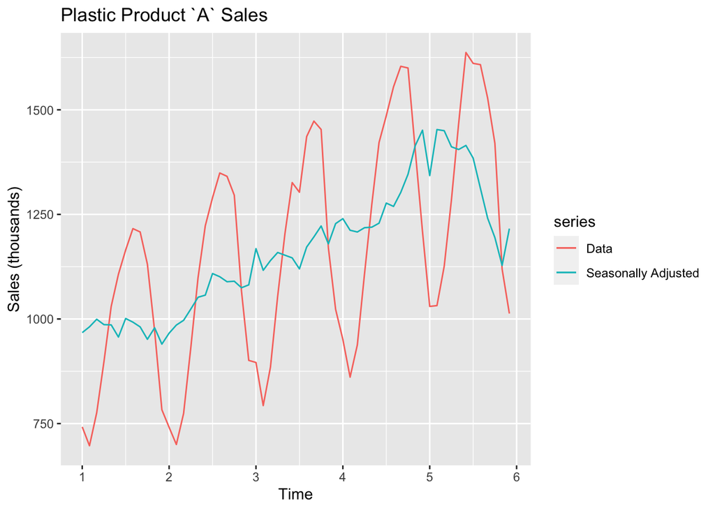

```r
plastics %>% decompose(type="multiplicative") -> fit
autoplot(plastics, series = "Data") +
  autolayer(seasadj(fit), series = "Seasonally Adjusted") +
  ylab("Sales (thousands)") +
  ggtitle("Plastic Product `A` Sales")
```

The blue line in the above graph, shows us the seasonally adjusted data, which depicts that plastic sales have an increasing sales with time(seasonally), with dips at few seasons.

**e. Change one observation to be an outlier (e.g., add 500 to one observation), and recompute the seasonally adjusted data. What is the effect of the outlier?**

**Answer**

The outlier should simply create a jump wherever it is seen, especially in the case of seasonally adjusted data. However, let’s see via our example:

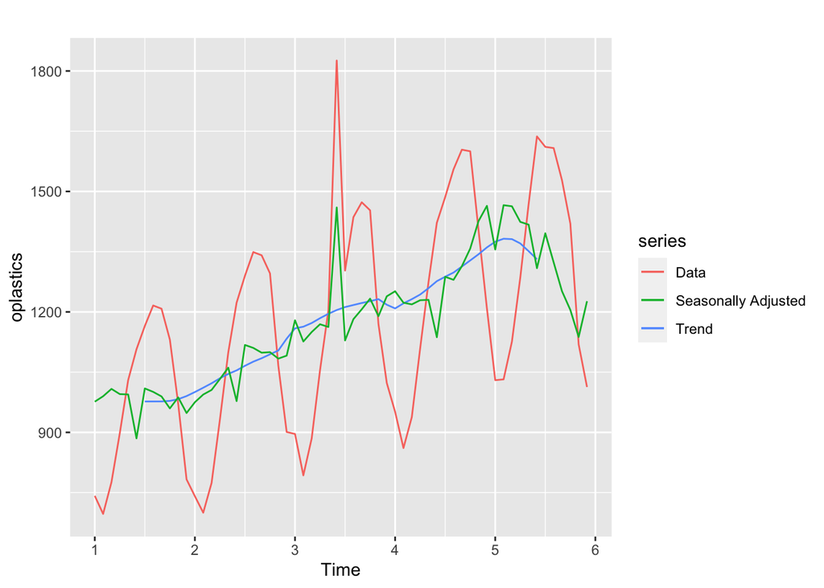

```r
oplastics <- plastics
oplastics[30] <- oplastics[30] + 500
oplastics %>% decompose(type="multiplicative") -> ofit
autoplot(oplastics, series = "Data") +
  autolayer(trendcycle(ofit), series = "Trend") +
  autolayer(seasadj(ofit), series = "Seasonally Adjusted")
```

- The effect of the outlier is a slight distortion in the trend’s straght line, but it has changed somewhat(in this case) with a slight spike/jump in the seasonally adjusted line or mostly absorbed into the remainder(for most of other cases) component, as evident from the graph above.
- Therefore it is likely that the seasonal component has changed with a slight spike where the outlier data is else rest hasn’t changed much because of the outlier.
- This conclusion is confimed by the decomposition plot below as well.

Let’s confirm our conclusion by using decomposition of multiolicative time series.

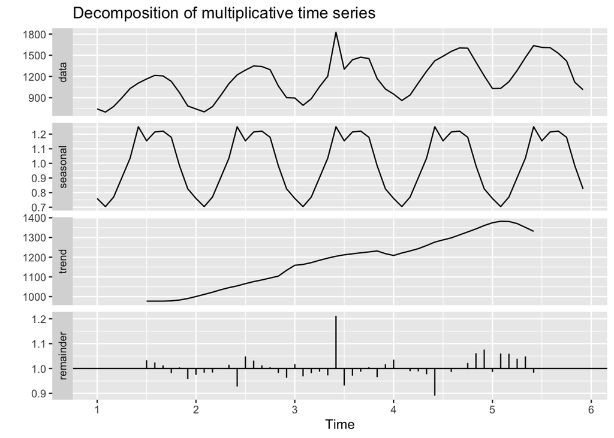

```r
oplastics %>% decompose(type="multiplicative") %>%
  autoplot()
```

**f. Does it make any difference if the outlier is near the end rather than in the middle of the time series?**

**Answer**

In theory it shouldn’t make any difference except the outlier should simply create a jump wherever it is seen, especially in the case of seasonally adjusted data. however, let’s confirm via our exapmle:

- Outlier at Beginning

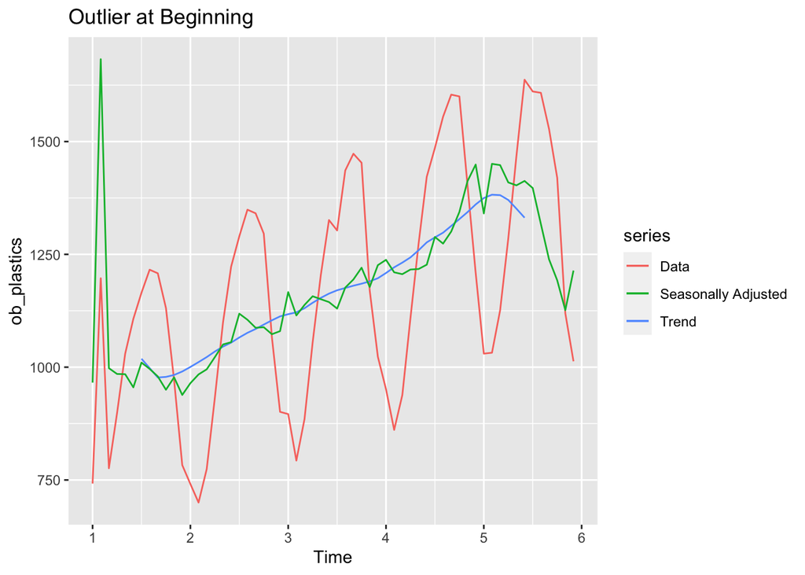

```r
#ob = outlier at beginning

ob_plastics <- plastics
ob_plastics[2] <- ob_plastics[2] + 500

ob_plastics %>% decompose(type="multiplicative") -> ob_fit
autoplot(ob_plastics, series = "Data") +
  autolayer(trendcycle(ob_fit), series = "Trend") +
  autolayer(seasadj(ob_fit), series = "Seasonally Adjusted")+
  ggtitle("Outlier at Beginning")
```

- Outlier at End

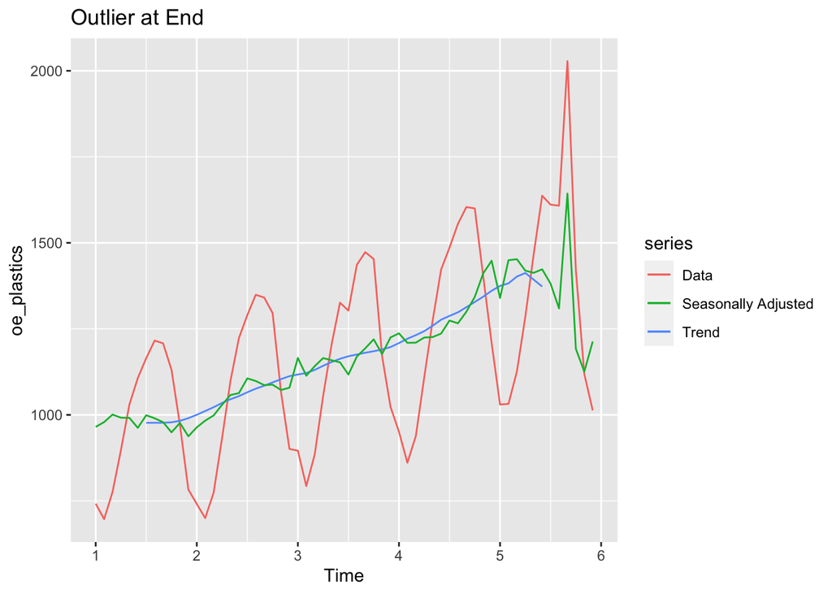

```r
#ob = outlier at end

oe_plastics <- plastics
oe_plastics[57] <- oe_plastics[57] + 500

oe_plastics %>% decompose(type="multiplicative") -> oe_fit
autoplot(oe_plastics, series = "Data") +
  autolayer(trendcycle(oe_fit), series = "Trend") +
  autolayer(seasadj(oe_fit), series = "Seasonally Adjusted")+
   ggtitle("Outlier at End")
```

As we see from two graphs above, adding outlier at the end or at the beginning, creates a jump or spike at that point of data or observation.

Let’s confirm our conclusion by using decomposition of multiolicative time series.

- Outlier at Beginning

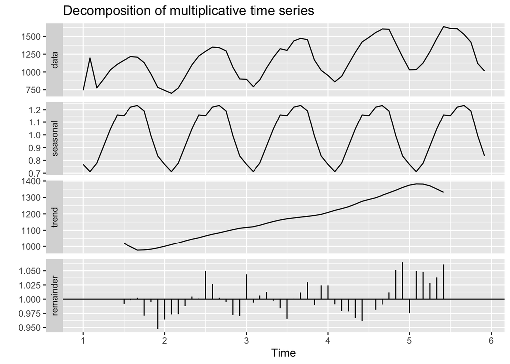

```r
ob_plastics %>% decompose(type="multiplicative") %>%
  autoplot()
```

Based on the graph there is a slight jump in the trend line towards at the beginning and almost no impact to the seasonality component.

- Outlier at End

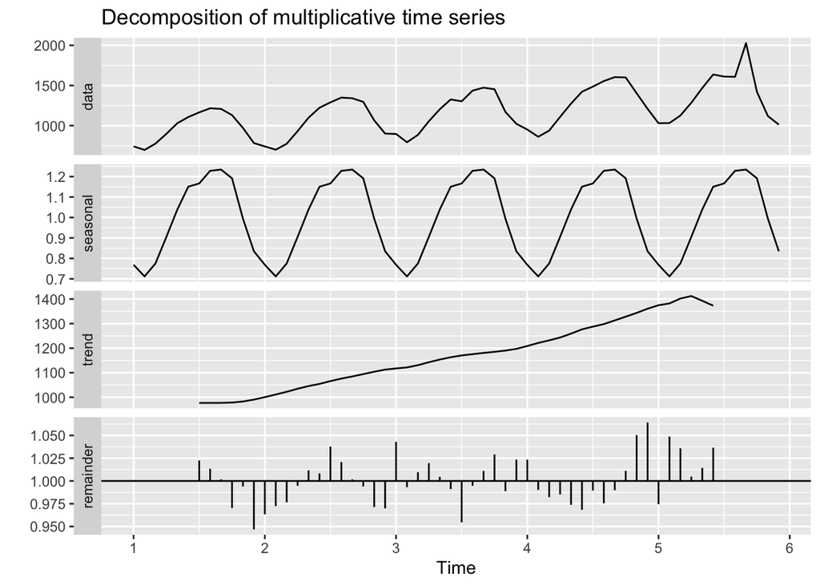

```r
oe_plastics %>% decompose(type="multiplicative") %>%
  autoplot()
```

Based on the graph there is a slight jump in the trend line towards the end and almost no impact to the seasonality component. The remainder has not captured the outlier. This may be due to the drawback of the classical decomposition which does not include end-points.

#### 6.3

**Recall your retail time series data (from Exercise 3 in Section 2.10). Decompose the series using X11. Does it reveal any outliers, or unusual features that you had not noticed previously?**

**Answer**

- Another popular method for decomposing quarterly and monthly data is the X11 method which originated in the US Census Bureau and Statistics Canada.
- X11 handles both additive and multiplicative decomposition. The process is entirely automatic and tends to be highly robust to outliers and level shifts in the time series.

```r
library(seasonal)
```

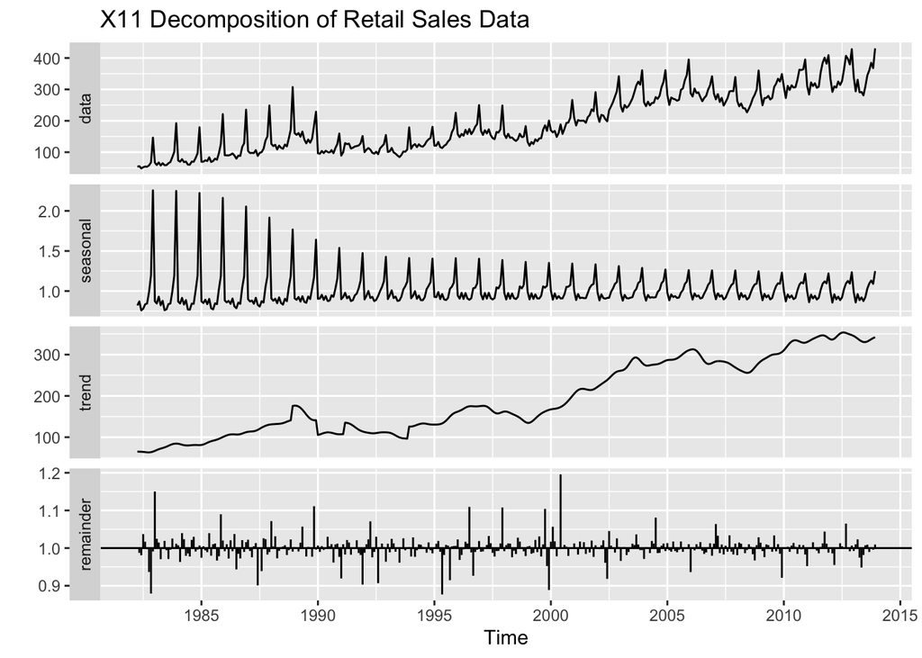

```r
retaildata <- readxl::read_excel("retail.xlsx", skip = 1)
retail <- ts(retaildata[, "A3349337W"], frequency = 12, start = c(1982, 4))
x11_retail <- seas(retail, x11="")
autoplot(x11_retail) +
  ggtitle("X11 Decomposition of Retail Sales Data")
```

- There are some spikes in the remainder early on 1983 and around 2000. That indicates the presense of some outliers.
- It is also interesting to note that the magnitude of the seasonal data decreases as the years go on, yet the trend continues upward. The reason maybe that seasonal swing was a lot stronger prior to 1990, although it’s hard to even see that in the regular plot of the data probably because `seasonally adjusted` series contain the remainder component as well as the trend-cycle as explained in exercise section 6.2(b). Therefore, they are not “smooth”, and “downturns” or “upturns” can be misleading.
- And if the purpose is to look for turning points in a series, and interpret any changes in direction, then it is better to use the trend-cycle component rather than the seasonally adjusted data.